# Final_Project-Unsupervised_Learning

```python
import pandas as pd
import numpy as np
import matplotlib.pyplot as plt
%matplotlib inline
import seaborn as sns
```

1. Data pre-processing – Perform all the necessary preprocessing on the data ready to be fed to an Unsupervised algorithm (10 marks)

```python
df=pd.read_csv('vehicle.csv')
```

```python
df.head()
```

|  | compactness | circularity | distance_circularity | radius_ratio | pr.axis_aspect_ratio | max.length_aspect_ratio | scatter_ratio | elongatedness | pr.axis_rectangularity | max.length_rectangularity | scaled_variance | scaled_variance.1 | scaled_radius_of_gyration | scaled_radius_of_gyration.1 | skewness_about | skewness_about.1 | skewness_about.2 | hollows_ratio | class |
| --- | --- | --- | --- | --- | --- | --- | --- | --- | --- | --- | --- | --- | --- | --- | --- | --- | --- | --- | --- |
| 0 | 95 | 48.0 | 83.0 | 178.0 | 72.0 | 10 | 162.0 | 42.0 | 20.0 | 159 | 176.0 | 379.0 | 184.0 | 70.0 | 6.0 | 16.0 | 187.0 | 197 | van |
| 1 | 91 | 41.0 | 84.0 | 141.0 | 57.0 | 9 | 149.0 | 45.0 | 19.0 | 143 | 170.0 | 330.0 | 158.0 | 72.0 | 9.0 | 14.0 | 189.0 | 199 | van |
| 2 | 104 | 50.0 | 106.0 | 209.0 | 66.0 | 10 | 207.0 | 32.0 | 23.0 | 158 | 223.0 | 635.0 | 220.0 | 73.0 | 14.0 | 9.0 | 188.0 | 196 | car |
| 3 | 93 | 41.0 | 82.0 | 159.0 | 63.0 | 9 | 144.0 | 46.0 | 19.0 | 143 | 160.0 | 309.0 | 127.0 | 63.0 | 6.0 | 10.0 | 199.0 | 207 | van |
| 4 | 85 | 44.0 | 70.0 | 205.0 | 103.0 | 52 | 149.0 | 45.0 | 19.0 | 144 | 241.0 | 325.0 | 188.0 | 127.0 | 9.0 | 11.0 | 180.0 | 183 | bus |

```python
df.shape
```

```
(846, 19)
```

```python
df.isnull().sum()
```

```
compactness                    0
circularity                    5
distance_circularity           4
radius_ratio                   6
pr.axis_aspect_ratio           2
max.length_aspect_ratio        0
scatter_ratio                  1
elongatedness                  1
pr.axis_rectangularity         3
max.length_rectangularity      0
scaled_variance                3
scaled_variance.1              2
scaled_radius_of_gyration      2
scaled_radius_of_gyration.1    4
skewness_about                 6
skewness_about.1               1
skewness_about.2               1
hollows_ratio                  0
class                          0
dtype: int64
```

##### Note:- We can see here there are few null values. We will deal with the null values in later part just before we split the data.

```python
df.shape
```

```
(846, 19)
```

```python
df['class'].value_counts()
```

```
car    429
bus    218
van    199
Name: class, dtype: int64
```

```python
# df[pd.isnull(df).any(axis=1)]
```

```python
df.info()
```

```
<class 'pandas.core.frame.DataFrame'>
RangeIndex: 846 entries, 0 to 845
Data columns (total 19 columns):
 #   Column                       Non-Null Count  Dtype
---  ------                       --------------  -----
 0   compactness                  846 non-null    int64
 1   circularity                  841 non-null    float64
 2   distance_circularity         842 non-null    float64
 3   radius_ratio                 840 non-null    float64
 4   pr.axis_aspect_ratio         844 non-null    float64
 5   max.length_aspect_ratio      846 non-null    int64
 6   scatter_ratio                845 non-null    float64
 7   elongatedness                845 non-null    float64
 8   pr.axis_rectangularity       843 non-null    float64
 9   max.length_rectangularity    846 non-null    int64
 10  scaled_variance              843 non-null    float64
 11  scaled_variance.1            844 non-null    float64
 12  scaled_radius_of_gyration    844 non-null    float64
 13  scaled_radius_of_gyration.1  842 non-null    float64
 14  skewness_about               840 non-null    float64
 15  skewness_about.1             845 non-null    float64
 16  skewness_about.2             845 non-null    float64
 17  hollows_ratio                846 non-null    int64
 18  class                        846 non-null    object
dtypes: float64(14), int64(4), object(1)
memory usage: 125.7+ KB
```

```python
df.describe().transpose().round(3)
```

|  | count | mean | std | min | 25% | 50% | 75% | max |
| --- | --- | --- | --- | --- | --- | --- | --- | --- |
| compactness | 846.0 | 93.678 | 8.234 | 73.0 | 87.00 | 93.0 | 100.0 | 119.0 |
| circularity | 841.0 | 44.829 | 6.152 | 33.0 | 40.00 | 44.0 | 49.0 | 59.0 |
| distance_circularity | 842.0 | 82.110 | 15.778 | 40.0 | 70.00 | 80.0 | 98.0 | 112.0 |
| radius_ratio | 840.0 | 168.888 | 33.520 | 104.0 | 141.00 | 167.0 | 195.0 | 333.0 |
| pr.axis_aspect_ratio | 844.0 | 61.679 | 7.891 | 47.0 | 57.00 | 61.0 | 65.0 | 138.0 |
| max.length_aspect_ratio | 846.0 | 8.567 | 4.601 | 2.0 | 7.00 | 8.0 | 10.0 | 55.0 |
| scatter_ratio | 845.0 | 168.902 | 33.215 | 112.0 | 147.00 | 157.0 | 198.0 | 265.0 |
| elongatedness | 845.0 | 40.934 | 7.816 | 26.0 | 33.00 | 43.0 | 46.0 | 61.0 |
| pr.axis_rectangularity | 843.0 | 20.582 | 2.593 | 17.0 | 19.00 | 20.0 | 23.0 | 29.0 |
| max.length_rectangularity | 846.0 | 147.999 | 14.516 | 118.0 | 137.00 | 146.0 | 159.0 | 188.0 |
| scaled_variance | 843.0 | 188.631 | 31.411 | 130.0 | 167.00 | 179.0 | 217.0 | 320.0 |
| scaled_variance.1 | 844.0 | 439.494 | 176.667 | 184.0 | 318.00 | 363.5 | 587.0 | 1018.0 |
| scaled_radius_of_gyration | 844.0 | 174.710 | 32.585 | 109.0 | 149.00 | 173.5 | 198.0 | 268.0 |
| scaled_radius_of_gyration.1 | 842.0 | 72.448 | 7.486 | 59.0 | 67.00 | 71.5 | 75.0 | 135.0 |
| skewness_about | 840.0 | 6.364 | 4.921 | 0.0 | 2.00 | 6.0 | 9.0 | 22.0 |
| skewness_about.1 | 845.0 | 12.602 | 8.936 | 0.0 | 5.00 | 11.0 | 19.0 | 41.0 |
| skewness_about.2 | 845.0 | 188.920 | 6.156 | 176.0 | 184.00 | 188.0 | 193.0 | 206.0 |
| hollows_ratio | 846.0 | 195.632 | 7.439 | 181.0 | 190.25 | 197.0 | 201.0 | 211.0 |

## Independent Variables

##### 1. There are 18 independent variables, if we remove 'class'.

##### 2. All these 18 independent variables are float64 & int64.

##### 3. We need to check the distribution of Independent Variables for Univariate Analysis

##### 4. We need to check correlation of features for bivariate analysis.

### Challeges :-

It is possible to have high correlation betweeen different featurs and hence we need to find out features with high correlation and drop the highly correlated independent feature.

Also, it is possible that many of the independent variables are not normally distributed and that can skew the model output. So, we need to transform the independent variables to normal distribution.

### Approach for Feature Engineering :-

Our approach here will be a **Two Layer** approach.

**First** we will not directly start making changes in the features. We will **first** directly go for implementing and fitting **models**. We will find Accuracies and Cross_val score of models without doing any feature Engineering.

In **second** stage, we will do all the feature Engineering and then we will try to find out the accuracies and cross_val scores after implementing feature Engineering.

And then we will **compare** the accuracies of the models before and after feature engineering to find out whehther the feature Engineering is needed or not.

## Dependent Variable

As we can see that the data is not balanced.

There are three classes in Dependent Variables(viz: Car,Bus,Van) and out of this one class has around 50% of the data and another two classes have 25% of the data each.

First we will check the accuracy of the models without making any change in the data imbalance. We may try to balance the data only if we are not able to find good accuracy with current state of data imbalance.

UniVariate Analysis

Let us draw a "BoxPlot" & "DistPlot" to check the outliers and distribution of individual Features

We will comment after we have gone through all the graphs.

```python
columns = list(df.columns)
columns.remove('class')
columns
```

```
['compactness',
 'circularity',
 'distance_circularity',
 'radius_ratio',
 'pr.axis_aspect_ratio',
 'max.length_aspect_ratio',
 'scatter_ratio',
 'elongatedness',
 'pr.axis_rectangularity',
 'max.length_rectangularity',
 'scaled_variance',
 'scaled_variance.1',
 'scaled_radius_of_gyration',
 'scaled_radius_of_gyration.1',
 'skewness_about',
 'skewness_about.1',
 'skewness_about.2',
 'hollows_ratio']
```

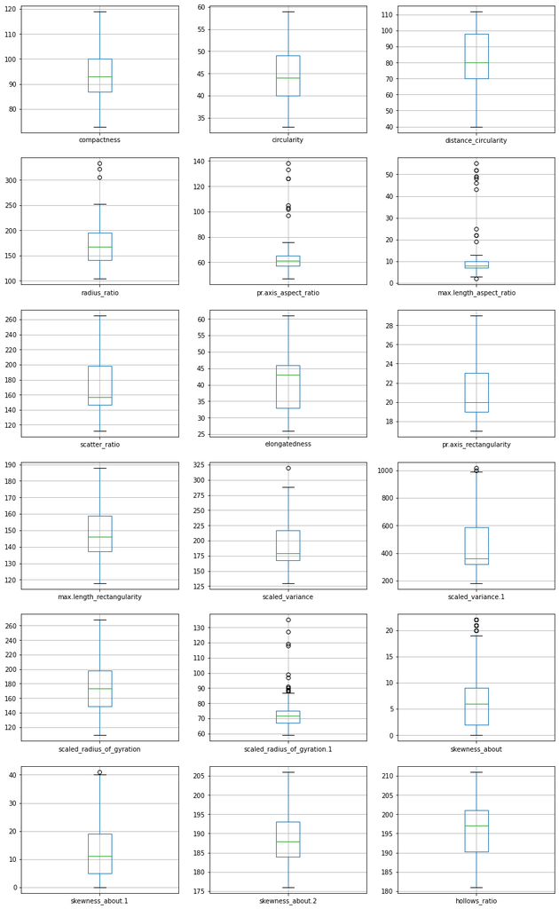

```python
figure=plt.figure(figsize=(15,30))
i=1

for x in columns:
  ax=plt.subplot(7,3,i)
  df.boxplot(x)
  i +=1
```

### Note:- There seems to be outliers with few of the independent variables.

1. radius_ratio
2. pr_axis.aspect_ratio
3. max.length_aspect_ratio
4. scales_radius_of_gyration.1
5. Skewness_about

# Let us check the distribution of independend variables

```python
import scipy.stats as stat
import pylab
```

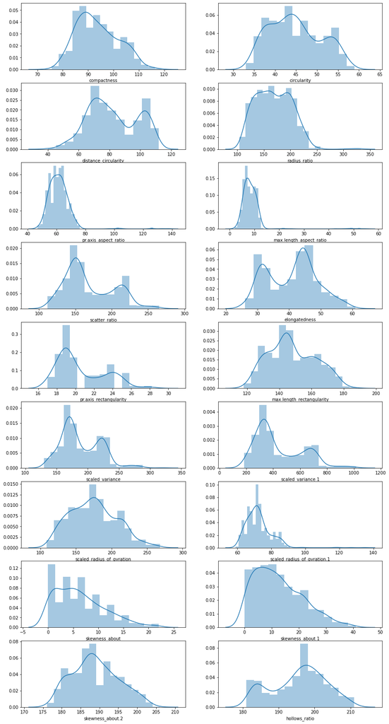

```python
figure=plt.figure(figsize=(15,30))
i=1

for x in columns:
  ax=plt.subplot(9,2,i)
  sns.distplot(df[x],kde=True)
  i +=1
#   ax=plt.subplot(18,2,i)
#   stat.probplot(df[x],dist='norm',plot=pylab)
#   i +=1
```

#### From the above distribution graph we can say that presence of outliers have skewed the normal distribution of few independent variables.

Variables with skewed distributions are:-

1. radius_ratio
2. pr_axis.aspect_ratio
3. max.length_aspect_ratio
4. scales_radius_of_gyration.1
5. Skewness_about

2. Understanding the attributes - Find relationship between different attributes (Independent variables) and choose carefully which all attributes have to be a part of the analysis and why (10 points)

# Bivariate Analysis

## Hence, we will go for correlation matrix as all the independent variables are numerical and not categorical.

```python
correl=df.corr()
```

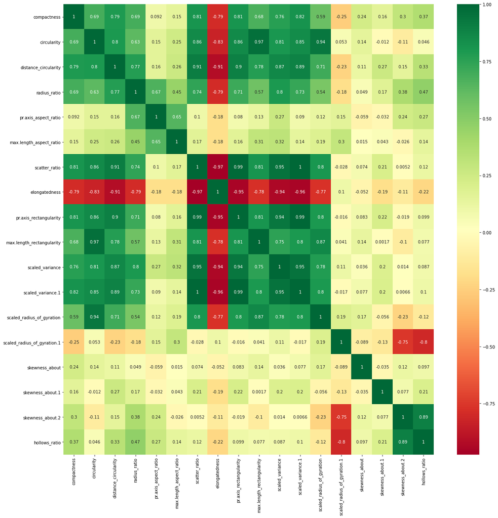

```python
pd.set_option('display.max_columns', None)
plt.figure(figsize=(20,20))

sns.heatmap(correl,annot = True,cmap="RdYlGn")
```

### Plotting correlation matrix with high correlation

```python
high_corr=correl[correl>0.8]
```

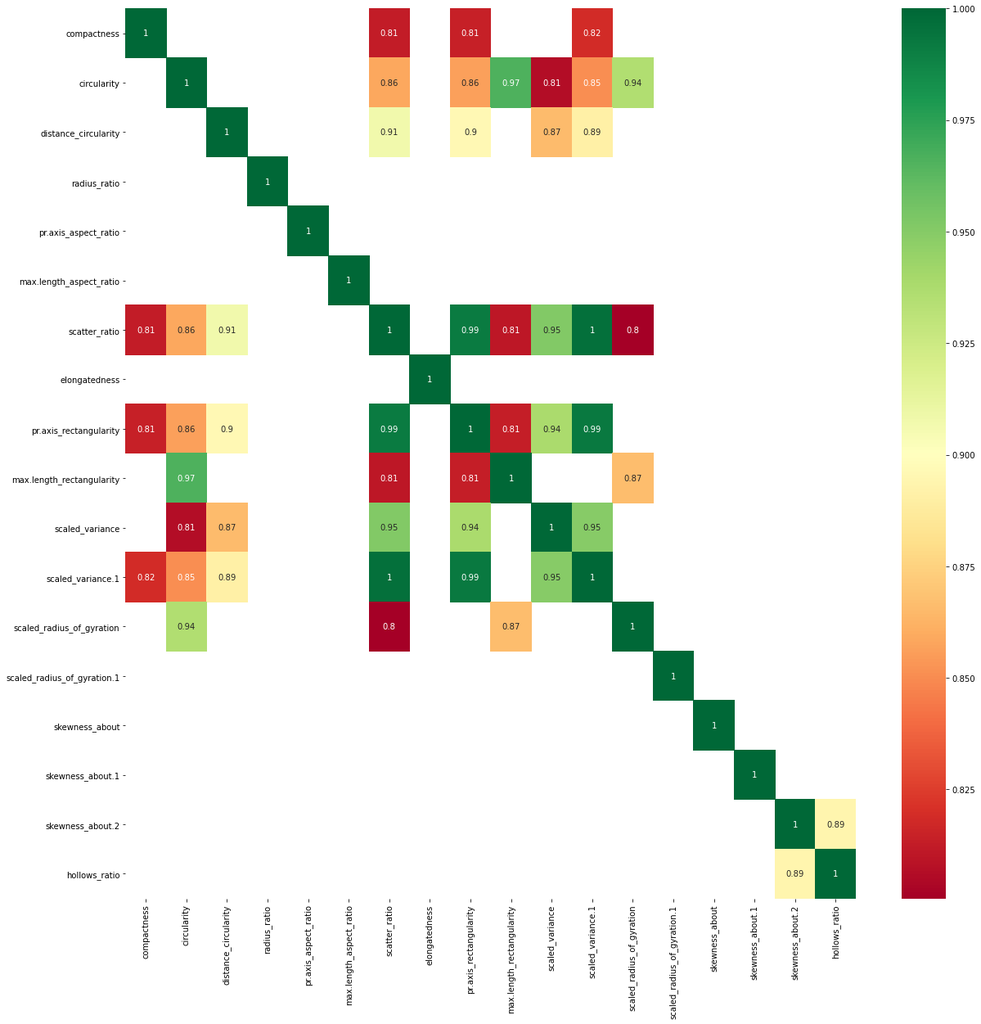

```python
plt.figure(figsize=(20,20))

sns.heatmap(high_corr,annot=True,cmap='RdYlGn')
```

>> Rather than manually counting the highly correlated features let us put that efforts in code.

```python
indices = np.where(correl > 0.8)   # Gives the index of the matrix elements who have corr > 0.8.
indices1 = [(correl.index[x], correl.columns[y]) for x, y in zip(*indices)
                                        if x != y and x < y]   # Gives the names of pair of features with high corrltn.
```

```python
indices
```

```
(array([ 0,  0,  0,  0,  1,  1,  1,  1,  1,  1,  1,  2,  2,  2,  2,  2,  3,
         4,  5,  6,  6,  6,  6,  6,  6,  6,  6,  6,  7,  8,  8,  8,  8,  8,
         8,  8,  8,  9,  9,  9,  9,  9, 10, 10, 10, 10, 10, 10, 11, 11, 11,
        11, 11, 11, 11, 12, 12, 12, 12, 13, 14, 15, 16, 16, 17, 17],
       dtype=int64),
 array([ 0,  6,  8, 11,  1,  6,  8,  9, 10, 11, 12,  2,  6,  8, 10, 11,  3,
         4,  5,  0,  1,  2,  6,  8,  9, 10, 11, 12,  7,  0,  1,  2,  6,  8,
         9, 10, 11,  1,  6,  8,  9, 12,  1,  2,  6,  8, 10, 11,  0,  1,  2,
         6,  8, 10, 11,  1,  6,  9, 12, 13, 14, 15, 16, 17, 16, 17],
       dtype=int64))
```

```python
indices1
```

```
[('compactness', 'scatter_ratio'),
 ('compactness', 'pr.axis_rectangularity'),
 ('compactness', 'scaled_variance.1'),
 ('circularity', 'scatter_ratio'),
 ('circularity', 'pr.axis_rectangularity'),
 ('circularity', 'max.length_rectangularity'),
 ('circularity', 'scaled_variance'),
 ('circularity', 'scaled_variance.1'),
 ('circularity', 'scaled_radius_of_gyration'),
 ('distance_circularity', 'scatter_ratio'),
 ('distance_circularity', 'pr.axis_rectangularity'),
 ('distance_circularity', 'scaled_variance'),
 ('distance_circularity', 'scaled_variance.1'),
 ('scatter_ratio', 'pr.axis_rectangularity'),
 ('scatter_ratio', 'max.length_rectangularity'),
 ('scatter_ratio', 'scaled_variance'),
 ('scatter_ratio', 'scaled_variance.1'),
 ('scatter_ratio', 'scaled_radius_of_gyration'),
 ('pr.axis_rectangularity', 'max.length_rectangularity'),
 ('pr.axis_rectangularity', 'scaled_variance'),
 ('pr.axis_rectangularity', 'scaled_variance.1'),
 ('max.length_rectangularity', 'scaled_radius_of_gyration'),
 ('scaled_variance', 'scaled_variance.1'),
 ('skewness_about.2', 'hollows_ratio')]
```

```python
columnList=[]
for k in range(len(indices1)):
    columnList.append(indices1[k][0])
```

```python
column_list=np.unique(columnList)
column_list    # This is a list of unique highly correlated features. This list we will later use to drop the columns with high correlation.
```

```
array(['circularity', 'compactness', 'distance_circularity',
       'max.length_rectangularity', 'pr.axis_rectangularity',
       'scaled_variance', 'scatter_ratio', 'skewness_about.2'],
      dtype='<U25')
```

1. Above is the list of unique columuns which have corr of greater than 0.8 with thier paired columns

2. Let us find out the correlated features for a list of Threshold Values

```python
corr_thresh=[0.6,0.7,0.8,0.9]
```

```python
length_drop_columns=[]
for threshold in corr_thresh:
     thresh_columnList=[]
     thresh_indices = np.where(correl > threshold)
     thresh_indices1 = [(correl.index[x], correl.columns[y]) for x, y in zip(*thresh_indices) if x != y and x < y]
     for k in range(len(thresh_indices1)):
             thresh_columnList.append(thresh_indices1[k][0])
     unique_features=np.unique(thresh_columnList)
     length_un_features=len(unique_features)
     length_drop_columns.append(length_un_features)
```

```python
length_drop_columns
```

```
[11, 10, 8, 5]
```

```python
feature_names=list(zip(corr_thresh,length_drop_columns))
df5=pd.DataFrame(feature_names,columns=['Correl_Thresh','No. of Columns with high corr'])
df5
```

|  | Correl_Thresh | No. of Columns with high corr |
| --- | --- | --- |
| 0 | 0.6 | 11 |
| 1 | 0.7 | 10 |
| 2 | 0.8 | 8 |
| 3 | 0.9 | 5 |

As we can see from above table and as should be obvious, as we increase the Threshold the number of high correlated columns decrease.

Later, at the end part of the project we will consider this in our feature engineering. We will drop columns which have a correlation of more than 0.8

```python
replace_class={
    'van' : 0,
    'car' : 1,
    'bus' : 2
 }
```

```python
df['class']=df['class'].map(replace_class)
```

```python
df.head(2)
```

|  | compactness | circularity | distance_circularity | radius_ratio | pr.axis_aspect_ratio | max.length_aspect_ratio | scatter_ratio | elongatedness | pr.axis_rectangularity | max.length_rectangularity | scaled_variance | scaled_variance.1 | scaled_radius_of_gyration | scaled_radius_of_gyration.1 | skewness_about | skewness_about.1 | skewness_about.2 | hollows_ratio | class |
| --- | --- | --- | --- | --- | --- | --- | --- | --- | --- | --- | --- | --- | --- | --- | --- | --- | --- | --- | --- |
| 0 | 95 | 48.0 | 83.0 | 178.0 | 72.0 | 10 | 162.0 | 42.0 | 20.0 | 159 | 176.0 | 379.0 | 184.0 | 70.0 | 6.0 | 16.0 | 187.0 | 197 | 0 |
| 1 | 91 | 41.0 | 84.0 | 141.0 | 57.0 | 9 | 149.0 | 45.0 | 19.0 | 143 | 170.0 | 330.0 | 158.0 | 72.0 | 9.0 | 14.0 | 189.0 | 199 | 0 |

```python
from sklearn.impute import SimpleImputer
from numpy import nan

imp = SimpleImputer(missing_values=nan, strategy='mean')
column=df.columns

df_final=imp.fit_transform(df)

df_final=pd.DataFrame(df_final,columns=column)
```

```python
df_final.isnull().sum().sum()
```

```
0
```

```python
X=df_final.drop(['class'],axis=1)
y=df_final['class']
```

```python
from sklearn.preprocessing import StandardScaler

column=X.columns
scaler=StandardScaler()
X=scaler.fit_transform(X)
X=pd.DataFrame(X,columns=column)
```

Let us first apply the above scaled data to unsupervised learning and then compare the labelling we get from unsupervised learning to the 'class' of orginial data and then check the accuracy of unsupervised learning.

# Hierarchical Clustering

```python
from sklearn.cluster import AgglomerativeClustering
```

```python
model = AgglomerativeClustering(n_clusters=3, affinity='euclidean',  linkage='average')
```

```python
model.fit(X)
```

```
AgglomerativeClustering(linkage='average', n_clusters=3)
```

```python
df1=df_final.copy()
df1['labels'] = model.labels_
df1.head(10)
```

|  | compactness | circularity | distance_circularity | radius_ratio | pr.axis_aspect_ratio | max.length_aspect_ratio | scatter_ratio | elongatedness | pr.axis_rectangularity | max.length_rectangularity | scaled_variance | scaled_variance.1 | scaled_radius_of_gyration | scaled_radius_of_gyration.1 | skewness_about | skewness_about.1 | skewness_about.2 | hollows_ratio | class | labels |
| --- | --- | --- | --- | --- | --- | --- | --- | --- | --- | --- | --- | --- | --- | --- | --- | --- | --- | --- | --- | --- |
| 0 | 95.0 | 48.000000 | 83.0 | 178.000000 | 72.0 | 10.0 | 162.0 | 42.0 | 20.0 | 159.0 | 176.0 | 379.0 | 184.0 | 70.0 | 6.0 | 16.0 | 187.0 | 197.0 | 0.0 | 0 |
| 1 | 91.0 | 41.000000 | 84.0 | 141.000000 | 57.0 | 9.0 | 149.0 | 45.0 | 19.0 | 143.0 | 170.0 | 330.0 | 158.0 | 72.0 | 9.0 | 14.0 | 189.0 | 199.0 | 0.0 | 0 |
| 2 | 104.0 | 50.000000 | 106.0 | 209.000000 | 66.0 | 10.0 | 207.0 | 32.0 | 23.0 | 158.0 | 223.0 | 635.0 | 220.0 | 73.0 | 14.0 | 9.0 | 188.0 | 196.0 | 1.0 | 0 |
| 3 | 93.0 | 41.000000 | 82.0 | 159.000000 | 63.0 | 9.0 | 144.0 | 46.0 | 19.0 | 143.0 | 160.0 | 309.0 | 127.0 | 63.0 | 6.0 | 10.0 | 199.0 | 207.0 | 0.0 | 0 |
| 4 | 85.0 | 44.000000 | 70.0 | 205.000000 | 103.0 | 52.0 | 149.0 | 45.0 | 19.0 | 144.0 | 241.0 | 325.0 | 188.0 | 127.0 | 9.0 | 11.0 | 180.0 | 183.0 | 2.0 | 1 |
| 5 | 107.0 | 44.828775 | 106.0 | 172.000000 | 50.0 | 6.0 | 255.0 | 26.0 | 28.0 | 169.0 | 280.0 | 957.0 | 264.0 | 85.0 | 5.0 | 9.0 | 181.0 | 183.0 | 2.0 | 0 |
| 6 | 97.0 | 43.000000 | 73.0 | 173.000000 | 65.0 | 6.0 | 153.0 | 42.0 | 19.0 | 143.0 | 176.0 | 361.0 | 172.0 | 66.0 | 13.0 | 1.0 | 200.0 | 204.0 | 2.0 | 0 |
| 7 | 90.0 | 43.000000 | 66.0 | 157.000000 | 65.0 | 9.0 | 137.0 | 48.0 | 18.0 | 146.0 | 162.0 | 281.0 | 164.0 | 67.0 | 3.0 | 3.0 | 193.0 | 202.0 | 0.0 | 0 |
| 8 | 86.0 | 34.000000 | 62.0 | 140.000000 | 61.0 | 7.0 | 122.0 | 54.0 | 17.0 | 127.0 | 141.0 | 223.0 | 112.0 | 64.0 | 2.0 | 14.0 | 200.0 | 208.0 | 0.0 | 0 |
| 9 | 93.0 | 44.000000 | 98.0 | 168.888095 | 62.0 | 11.0 | 183.0 | 36.0 | 22.0 | 146.0 | 202.0 | 505.0 | 152.0 | 64.0 | 4.0 | 14.0 | 195.0 | 204.0 | 1.0 | 0 |

```python
df1.shape
```

```
(846, 20)
```

```python
df2 = df1.groupby(['labels'])
df2.mean()
```

| labels | compactness | circularity | distance_circularity | radius_ratio | pr.axis_aspect_ratio | max.length_aspect_ratio | scatter_ratio | elongatedness | pr.axis_rectangularity | max.length_rectangularity | scaled_variance | scaled_variance.1 | scaled_radius_of_gyration | scaled_radius_of_gyration.1 | skewness_about | skewness_about.1 | skewness_about.2 | hollows_ratio | class |
| --- | --- | --- | --- | --- | --- | --- | --- | --- | --- | --- | --- | --- | --- | --- | --- | --- | --- | --- | --- |
| 0 | 93.736277 | 44.824754 | 82.152079 | 167.940726 | 61.157945 | 8.178998 | 169.073868 | 40.898489 | 20.596357 | 147.960621 | 188.128751 | 440.488053 | 174.648472 | 72.094023 | 6.37731 | 12.621244 | 188.960524 | 195.663484 | 1.027446 |
| 1 | 86.714286 | 45.000000 | 76.714286 | 258.857143 | 113.142857 | 49.285714 | 150.285714 | 44.857143 | 19.142857 | 151.571429 | 230.000000 | 332.714286 | 180.285714 | 105.857143 | 4.00000 | 10.857143 | 184.142857 | 191.857143 | 0.571429 |
| 2 | 94.000000 | 47.000000 | 85.000000 | 333.000000 | 138.000000 | 49.000000 | 155.000000 | 43.000000 | 19.000000 | 155.000000 | 320.000000 | 354.000000 | 187.000000 | 135.000000 | 12.00000 | 9.000000 | 188.000000 | 196.000000 | 0.000000 |

```python
from scipy.cluster.hierarchy import cophenet, dendrogram, linkage
from scipy.spatial.distance import pdist  #Pairwise distribution between data points
```

```python
Z = linkage(X, metric='euclidean', method='average')
c, X_dists = cophenet(Z , pdist(X))

c
```

```
0.773723281373438
```

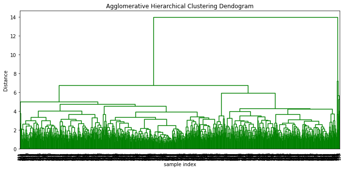

```python
plt.figure(figsize=(10, 5))
plt.title('Agglomerative Hierarchical Clustering Dendogram')
plt.xlabel('sample index')
plt.ylabel('Distance')
dendrogram(Z, leaf_rotation=90.,color_threshold = 40, leaf_font_size=8. )
plt.tight_layout()
```

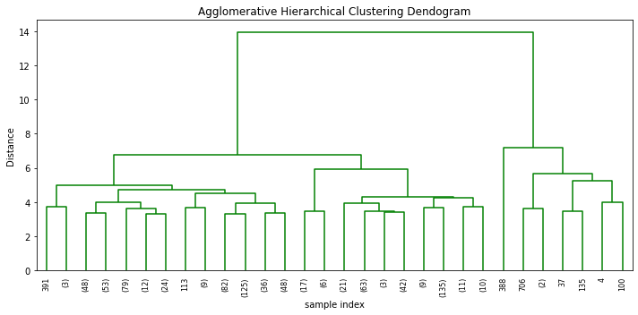

```python
plt.figure(figsize=(10, 5))
plt.title('Agglomerative Hierarchical Clustering Dendogram')
plt.xlabel('sample index')
plt.ylabel('Distance')
dendrogram(Z,truncate_mode='lastp', leaf_rotation=90.,color_threshold = 40, leaf_font_size=8. )
plt.tight_layout()
```

## let us manually find the accuracy of unsupervised clustering versus real labels of 'class' i.e. van,bus,car

```python
df1.head(2)
```

|  | compactness | circularity | distance_circularity | radius_ratio | pr.axis_aspect_ratio | max.length_aspect_ratio | scatter_ratio | elongatedness | pr.axis_rectangularity | max.length_rectangularity | scaled_variance | scaled_variance.1 | scaled_radius_of_gyration | scaled_radius_of_gyration.1 | skewness_about | skewness_about.1 | skewness_about.2 | hollows_ratio | class | labels |
| --- | --- | --- | --- | --- | --- | --- | --- | --- | --- | --- | --- | --- | --- | --- | --- | --- | --- | --- | --- | --- |
| 0 | 95.0 | 48.0 | 83.0 | 178.0 | 72.0 | 10.0 | 162.0 | 42.0 | 20.0 | 159.0 | 176.0 | 379.0 | 184.0 | 70.0 | 6.0 | 16.0 | 187.0 | 197.0 | 0.0 | 0 |
| 1 | 91.0 | 41.0 | 84.0 | 141.0 | 57.0 | 9.0 | 149.0 | 45.0 | 19.0 | 143.0 | 170.0 | 330.0 | 158.0 | 72.0 | 9.0 | 14.0 | 189.0 | 199.0 | 0.0 | 0 |

Let us check the distribution of Dependent variables of Unsupervised Learning

```python
df1['labels'].value_counts()
```

```
0    838
1      7
2      1
Name: labels, dtype: int64
```

Let us check the distribution of Dependent variables of original data

```python
df1['class'].value_counts()
```

```
1.0    429
2.0    218
0.0    199
Name: class, dtype: int64
```

Conclusion:- As we see, there is a vast difference between the Dependent Variable distribution of three classes of original data and of Supervised Learning

So, we can say that we have not got good accuracy for unsupervised learning

# Implement SVM Model

3. Split the data into train and test (Suggestion: specify “random state” if you are using train_test_split from Sklearn) (5 marks)

```python
from sklearn.model_selection import train_test_split

x_train,x_test,y_train,y_test=train_test_split(X,y,test_size=0.3,random_state=2)
```

4. Train a Support vector machine using the train set and get the accuracy on the test set (10 marks)

```python
from sklearn.svm import SVC
svm=SVC()
```

```python
test_acc_before_gridsearch=[] #preparing the list of accuracies before and after gridsearch and cross_val_score
test_acc_after_gridsearch=[]  #to be able to compare the accuracies across models at the end of the project.
cross_valdtn_score=[]         #
```

```python
svm.fit(x_train,y_train)
```

```
SVC()
```

```python
a=svm.score(x_test,y_test)
a
test_acc_before_gridsearch.append(a) #appending the accuracy to list.
```

```python
param = {
    "C"      : [0.10,0.25,0.3,0.5,0.9,1,1.5,2,3,5,7,9],
    "gamma"  : [0.01,0.1,0.1,0.15,0.20,0.25,0.30,0.5,0.75,1,2],
    "kernel" : ['linear','rbf', 'poly', 'sigmoid']
}
```

```python
from sklearn.model_selection import GridSearchCV
SVM_GridSearch = GridSearchCV(estimator=SVC(),param_grid=param,cv=10,n_jobs =-1,verbose = 3)
SVM_GridSearch.fit(X,y)
```

```
Fitting 10 folds for each of 528 candidates, totalling 5280 fits
```

```
[Parallel(n_jobs=-1)]: Using backend LokyBackend with 8 concurrent workers.
[Parallel(n_jobs=-1)]: Done  16 tasks      | elapsed:    2.5s
[Parallel(n_jobs=-1)]: Done 400 tasks      | elapsed:    4.4s
[Parallel(n_jobs=-1)]: Done 1680 tasks      | elapsed:   10.6s
[Parallel(n_jobs=-1)]: Done 3472 tasks      | elapsed:   19.2s
[Parallel(n_jobs=-1)]: Done 5280 out of 5280 | elapsed:   28.3s finished
```

```
GridSearchCV(cv=10, estimator=SVC(), n_jobs=-1,
             param_grid={'C': [0.1, 0.25, 0.3, 0.5, 0.9, 1, 1.5, 2, 3, 5, 7, 9],
                         'gamma': [0.01, 0.1, 0.1, 0.15, 0.2, 0.25, 0.3, 0.5,
                                   0.75, 1, 2],
                         'kernel': ['linear', 'rbf', 'poly', 'sigmoid']},
             verbose=3)
```

```python
SVM_GridSearch.best_estimator_
```

```
SVC(C=2, gamma=0.1)
```

```python
SVM_CF=SVM_GridSearch.best_estimator_
SVM_CF.fit(x_train,y_train)
b=SVM_CF.score(x_test,y_test)
print(b)
test_acc_after_gridsearch.append(b)#appending the accuracy to list.
```

```
0.9645669291338582
```

5. Perform K-fold cross validation and get the cross validation score of the model (optional)

```python
from sklearn.model_selection import cross_val_score
SVM_model=SVC(C=9,gamma=0.1)
```

```python
from sklearn.model_selection import ShuffleSplit
n_samples = X.shape[0]
cv = ShuffleSplit(n_splits=5, test_size=0.3, random_state=1)
c=cross_val_score(SVM_model, X, y, cv=cv)
c
cross_valdtn_score.append(c.round(4))#appending the cross_val_score to list.
cross_valdtn_score
```

```
[array([0.9646, 0.9528, 0.9567, 0.9803, 0.9724])]
```

6. Use PCA from Scikit learn, extract Principal Components that capture about 95% of the variance in the data – (10 points)

```python
from sklearn.decomposition import PCA
```

```python
pca3 = PCA(n_components=8)
pca3.fit(X)
# print(pca3.components_)
print(pca3.explained_variance_ratio_)
Xpca3 = pca3.transform(X)
```

```
[0.52206485 0.16736054 0.10562382 0.0654932  0.05089389 0.02992458
 0.01989681 0.01229998]
```

7. Repeat steps 3,4 and 5 but this time, use Principal Components instead of the original data. And the accuracy score should be on the same rows of test data that were used earlier. (hint: set the same random state) (20marks)

```python
from sklearn.model_selection import train_test_split

PCA_x_train,PCA_x_test,PCA_y_train,PCA_y_test=train_test_split(Xpca3,y,test_size=0.3,random_state=2)
```

```python
svm.fit(PCA_x_train,PCA_y_train)
d=svm.score(PCA_x_test,PCA_y_test)
print(d)
test_acc_before_gridsearch.append(d)
```

```
0.9212598425196851
```

```python
from sklearn.model_selection import GridSearchCV
PCA_SVM_GridSearch = GridSearchCV(estimator=SVC(),param_grid=param,cv=10,n_jobs =-1,verbose = 3)
PCA_SVM_GridSearch.fit(Xpca3,y)
```

```
Fitting 10 folds for each of 528 candidates, totalling 5280 fits
```

```
[Parallel(n_jobs=-1)]: Using backend LokyBackend with 8 concurrent workers.
[Parallel(n_jobs=-1)]: Done  16 tasks      | elapsed:    0.0s
[Parallel(n_jobs=-1)]: Done 624 tasks      | elapsed:    3.2s
[Parallel(n_jobs=-1)]: Done 1600 tasks      | elapsed:   10.5s
[Parallel(n_jobs=-1)]: Done 2752 tasks      | elapsed:   22.2s
[Parallel(n_jobs=-1)]: Done 3904 tasks      | elapsed:   35.9s
[Parallel(n_jobs=-1)]: Done 4964 tasks      | elapsed:   52.5s
[Parallel(n_jobs=-1)]: Done 5280 out of 5280 | elapsed:  1.1min finished
```

```
GridSearchCV(cv=10, estimator=SVC(), n_jobs=-1,
             param_grid={'C': [0.1, 0.25, 0.3, 0.5, 0.9, 1, 1.5, 2, 3, 5, 7, 9],
                         'gamma': [0.01, 0.1, 0.1, 0.15, 0.2, 0.25, 0.3, 0.5,
                                   0.75, 1, 2],
                         'kernel': ['linear', 'rbf', 'poly', 'sigmoid']},
             verbose=3)
```

```python
PCA_SVM_GridSearch.best_estimator_
```

```
SVC(C=9, gamma=0.1)
```

```python
PCA_SVM_CF=SVM_GridSearch.best_estimator_
PCA_SVM_CF.fit(PCA_x_train,PCA_y_train)
e=PCA_SVM_CF.score(PCA_x_test,PCA_y_test)
print(e)
test_acc_after_gridsearch.append(e)
```

```
0.9251968503937008
```

```python
from sklearn.model_selection import cross_val_score
```

```python
from sklearn.model_selection import ShuffleSplit
PCA_cv = ShuffleSplit(n_splits=5, test_size=0.3, random_state=1)
f=cross_val_score(PCA_SVM_CF, Xpca3, y, cv=PCA_cv)
cross_valdtn_score.append(f.round(4))
```

```python
cross_val_score(SVM_model, X, y, cv=cv)
```

```
array([0.96456693, 0.95275591, 0.95669291, 0.98031496, 0.97244094])
```

Feature Engineering

# Let's drop highly correlated columns and check the accuracy of the model

```python
df_final.head()
```

|  | compactness | circularity | distance_circularity | radius_ratio | pr.axis_aspect_ratio | max.length_aspect_ratio | scatter_ratio | elongatedness | pr.axis_rectangularity | max.length_rectangularity | scaled_variance | scaled_variance.1 | scaled_radius_of_gyration | scaled_radius_of_gyration.1 | skewness_about | skewness_about.1 | skewness_about.2 | hollows_ratio | class |
| --- | --- | --- | --- | --- | --- | --- | --- | --- | --- | --- | --- | --- | --- | --- | --- | --- | --- | --- | --- |
| 0 | 95.0 | 48.0 | 83.0 | 178.0 | 72.0 | 10.0 | 162.0 | 42.0 | 20.0 | 159.0 | 176.0 | 379.0 | 184.0 | 70.0 | 6.0 | 16.0 | 187.0 | 197.0 | 0.0 |
| 1 | 91.0 | 41.0 | 84.0 | 141.0 | 57.0 | 9.0 | 149.0 | 45.0 | 19.0 | 143.0 | 170.0 | 330.0 | 158.0 | 72.0 | 9.0 | 14.0 | 189.0 | 199.0 | 0.0 |
| 2 | 104.0 | 50.0 | 106.0 | 209.0 | 66.0 | 10.0 | 207.0 | 32.0 | 23.0 | 158.0 | 223.0 | 635.0 | 220.0 | 73.0 | 14.0 | 9.0 | 188.0 | 196.0 | 1.0 |
| 3 | 93.0 | 41.0 | 82.0 | 159.0 | 63.0 | 9.0 | 144.0 | 46.0 | 19.0 | 143.0 | 160.0 | 309.0 | 127.0 | 63.0 | 6.0 | 10.0 | 199.0 | 207.0 | 0.0 |
| 4 | 85.0 | 44.0 | 70.0 | 205.0 | 103.0 | 52.0 | 149.0 | 45.0 | 19.0 | 144.0 | 241.0 | 325.0 | 188.0 | 127.0 | 9.0 | 11.0 | 180.0 | 183.0 | 2.0 |

```python
df_final.drop(column_list,axis=1,inplace=True)
```

```python
df_final.shape
```

```
(846, 11)
```

```python
X_drop_corr=df_final.drop(['class'],axis=1)
y=df['class']
```

```python
from sklearn.preprocessing import StandardScaler

column=X_drop_corr.columns
scaler=StandardScaler()
X_drop_corr=scaler.fit_transform(X_drop_corr)
X_drop_corr=pd.DataFrame(X_drop_corr,columns=column)
```

```python
from sklearn.model_selection import train_test_split

x_train,x_test,y_train,y_test=train_test_split(X_drop_corr,y,test_size=0.3,random_state=2)
```

```python
from sklearn.svm import SVC
svm=SVC()
```

```python
svm.fit(x_train,y_train)
```

```
SVC()
```

```python
q=svm.score(x_test,y_test)
q
test_acc_before_gridsearch.append(q)
```

```python
param = {
    "C"      : [0.10,0.25,0.3,0.5,0.9,1,1.5,2,3,5,7,9],
    "gamma"  : [0.01,0.1,0.1,0.15,0.20,0.25,0.30,0.5,0.75,1,2],
    "kernel" : ['linear','rbf', 'poly', 'sigmoid']
}
```

```python
from sklearn.model_selection import GridSearchCV
corr_drop_SVM_GridSearch = GridSearchCV(estimator=SVC(),param_grid=param,cv=10,n_jobs =-1,verbose = 3)
corr_drop_SVM_GridSearch.fit(X_drop_corr,y)
```

```
Fitting 10 folds for each of 528 candidates, totalling 5280 fits
```

```
[Parallel(n_jobs=-1)]: Using backend LokyBackend with 8 concurrent workers.
[Parallel(n_jobs=-1)]: Done  16 tasks      | elapsed:    0.1s
[Parallel(n_jobs=-1)]: Done 368 tasks      | elapsed:    2.5s
[Parallel(n_jobs=-1)]: Done 1008 tasks      | elapsed:    7.0s
[Parallel(n_jobs=-1)]: Done 1904 tasks      | elapsed:   12.9s
[Parallel(n_jobs=-1)]: Done 3056 tasks      | elapsed:   20.7s
[Parallel(n_jobs=-1)]: Done 4464 tasks      | elapsed:   31.0s
[Parallel(n_jobs=-1)]: Done 5280 out of 5280 | elapsed:   38.0s finished
```

```
GridSearchCV(cv=10, estimator=SVC(), n_jobs=-1,
             param_grid={'C': [0.1, 0.25, 0.3, 0.5, 0.9, 1, 1.5, 2, 3, 5, 7, 9],
                         'gamma': [0.01, 0.1, 0.1, 0.15, 0.2, 0.25, 0.3, 0.5,
                                   0.75, 1, 2],
                         'kernel': ['linear', 'rbf', 'poly', 'sigmoid']},
             verbose=3)
```

```python
corr_drop_SVM_GridSearch.best_estimator_
```

```
SVC(C=9, gamma=0.1)
```

```python
corr_drop_SVM_CF=corr_drop_SVM_GridSearch.best_estimator_
corr_drop_SVM_CF.fit(x_train,y_train)
acc_score=corr_drop_SVM_CF.score(x_test,y_test)
print(acc_score)
test_acc_after_gridsearch.append(acc_score)
```

```
0.9448818897637795
```

```python
from sklearn.model_selection import ShuffleSplit
corr_drop_cv = ShuffleSplit(n_splits=5, test_size=0.3, random_state=1)
valscore=cross_val_score(PCA_SVM_CF, X_drop_corr, y, cv=corr_drop_cv)
cross_valdtn_score.append(valscore.round(4))
```

8. Compare the accuracy scores and cross validation scores of Support vector machines – one trained using raw data and the other using Principal Components, and mention your findings (5 points)

# Selecting Best Model

```python
# for train_index,test_index in PCA_cv.split(Xpca3):
#     print(f" {train_index}  \n\n\n {test_index}")
#     break
```

```python
# for train_index,test_index in cv.split(X):
#     print(f" {train_index}  \n\n\n {test_index}")
#     break
```

```python
data=list(zip(test_acc_before_gridsearch,test_acc_after_gridsearch,cross_valdtn_score))

compare_score=pd.DataFrame(data, index = ['SVM_before_PCA','SVM_after_PCA','SVM_after_drop_columns'],
                           columns=['test_acc_before_gridsearch','test_acc_after_gridsearch','cross_valdtn_score'])
```

```python
compare_score
```

|  | test_acc_before_gridsearch | test_acc_after_gridsearch | cross_valdtn_score |
| --- | --- | --- | --- |
| SVM_before_PCA | 0.964567 | 0.964567 | [0.9646, 0.9528, 0.9567, 0.9803, 0.9724] |
| SVM_after_PCA | 0.921260 | 0.925197 | [0.937, 0.9449, 0.9252, 0.9646, 0.9606] |
| SVM_after_drop_columns | 0.909449 | 0.944882 | [0.9134, 0.9213, 0.8819, 0.937, 0.9646] |

Above is the DataFrame for comparison of SVM model

The table above gives model accuracies before PCA and after PCA and also after doing feature engineering and dropping few columns

As we can see from above table that, SVM test accuracy for "test_acc_before_gridsearch" is highest for the SVM model before performing PCA.

Same is also true for "test_acc_after_gridsearch." Accuracy for SVM model before PCA is highest.

All this points to one truth, that performing PCA or performing feature engineering by dropping highly correlated columns only drops the accuracies.

This happens because in both(PCA and feature engineering of dropping columns) we are acutally losing some information which plays a role in getting higher accuracy.

**But there is a twist**:- If we check the range of **"cross_valdtn_scores"** a.k.a **Cross-Validation-Scores** for all the three models we see that for models **"SVM_after_PCA"** & **"SVM_after_drop_columns"** the highest accuracy is **96.46%.**

Also, the highest accuracy for model **"SVM_before_PCA"** is **98%.**

Not much information is lost when we do **feature engineering** and **drop 8 columns.** Hence dropping columns can be a valid option. We have dropped 8 columns and hence **the total columns used as the input to model is 10(after dropping the Dependent Variable).**

Conclusion: In the table we see that for the last two models, accuracy is 96.46% which is just 1.5% less than the model "SVM_before_PCA."